# Wk5_Take_Home

Sam Fritz-Schreck

2024-02-05

# Applying Distance/Similarity Measures

In this lab, you’ll apply distance and similarity measures discussed this week to solve two practical, real-world problems:

Entity Resolution: you will conduct entity resolution to identify records that match between two entity spreadsheets.

Finding Similar Documents: you will develop a method for helping NPS thesis students find references that are applicable to their research work

Important Note: The problems you are attempting to solve for this lab are both straightforward (easy to understand the goal) but the solutions to them are very complex, with a vast decision space to explore for possible solutions. It is highly recommended that for each problem you first implement a simple and straightforward approach that completely solves the problem and then iteratively improve your solution with more sophisticated approaches as time allows.

## Practical Entity Resolution

```r
getwd()
```

```
## [1] "/home/sam/Documents/OA4118-Stat_ML/Lab2"
```

```r
library(data.table)
df_A = read_csv('./WK5LabData/ERData/ASample.csv',col_types = cols(.default = col_character()))
df_B = read_csv('./WK5LabData/ERData/BSample.csv',col_types = cols(.default = col_character()))


setnames(df_A, old=colnames(df_A), new = c('ID','SSN','First','Middle','Last','Add_Num', 'Street', 'Apt_Num', 'City', 'State', 'Zip'))
setnames(df_B, old=colnames(df_B), new = c('ID','SSN','First','Middle','Last','Add_Num', 'Street', 'Apt_Num', 'City', 'State', 'Zip'))
summary(df_A)
```

```
##       ID                SSN               First              Middle
##  Length:1565        Length:1565        Length:1565        Length:1565
##  Class :character   Class :character   Class :character   Class :character
##  Mode  :character   Mode  :character   Mode  :character   Mode  :character
##      Last             Add_Num             Street            Apt_Num
##  Length:1565        Length:1565        Length:1565        Length:1565
##  Class :character   Class :character   Class :character   Class :character
##  Mode  :character   Mode  :character   Mode  :character   Mode  :character
##      City              State               Zip
##  Length:1565        Length:1565        Length:1565
##  Class :character   Class :character   Class :character
##  Mode  :character   Mode  :character   Mode  :character
```

```r
summary(df_B)
```

```
##       ID                SSN               First              Middle
##  Length:1367        Length:1367        Length:1367        Length:1367
##  Class :character   Class :character   Class :character   Class :character
##  Mode  :character   Mode  :character   Mode  :character   Mode  :character
##      Last             Add_Num             Street            Apt_Num
##  Length:1367        Length:1367        Length:1367        Length:1367
##  Class :character   Class :character   Class :character   Class :character
##  Mode  :character   Mode  :character   Mode  :character   Mode  :character
##      City              State               Zip
##  Length:1367        Length:1367        Length:1367
##  Class :character   Class :character   Class :character
##  Mode  :character   Mode  :character   Mode  :character
```

The datasets zip file you were provided for this lab contains a folder named ER_Datasets containing two .csv files named ASample and BSample. Each of these spreadsheets contains (synthetic) records of people in a similar format. Your task is to write a function that performs the following tasks:

```
Your function should take as inputs (function arguments) the names of two dataframes (you may add additional arguments such as specifying the distance measure to use if you wish)

Your function should calculate a score for each of the possible matches between the entities in the two spreadsheets.

Your function should return a sorted dataframe in descending order of the recommended matches (i.e. the best matches should appear first in the dataframe)

Fields/attributes used to match the entities should be included in your output for manual review by humans (i.e. you should group the two last names together, the two first names together, etc., so that humans can review your assorted recommended matches)
```

```r
comparisons = compare.linkage(df_A, df_B, blockfld = c(3,5), exclude = c(1,4,6:11), strcmp = T)
```

It is up to you to determine the exact details of how your function wll be implemented. For your lab submission, you should apply your function to the task of matching the two dataframes above. Please provde the following:

```
In your written submssion, provide a brief overview/discussion of the approach/scoring function you are applying in your function (i.e. defend/argue for your solution). Which fields (if any) are you blocking on and why?

In your written submisson, provide the number of comparisons your function performs when applied to this dataset.
```

```r
summary(comparisons)
```

```
##
## Linkage Data Set
##
## 1565 records in data set 1
## 1367 records in data set 2
## 42 record pairs
##
## 0 matches
## 0 non-matches
## 42 pairs with unknown status
```

```
In your written report, assert how many matches do you believe there are between the two spreadsheets (note that you may perform manual review of the results returned by your function).
```

```r
scores = comparisons$pairs
results.list <- list()
for (i in 1:length(scores$id1)){
  results.list[[i]]<-c(sum(scores[i,c(3:5)]),                    # total score calculated by summing pairs columns
                       scores$SSN[i],
                       df_A$SSN[scores$id1[i]],
                       df_B$SSN[scores$id2[i]]
  )
}

results<-data.frame(do.call(rbind, results.list), stringsAsFactors=FALSE)
colnames(results)<-c("Score", "SSN_Score", "SSN1", "SSN2")

results$Score <- as.numeric(results$Score)/3    # divide by the number of columns we used for fuzzy matching

results <- results[order(results$Score),]
results
```

```
##        Score         SSN_Score      SSN1      SSN2
## 8  0.9012346 0.703703703703704 430181172         0
## 7  0.9412698 0.823809523809524 502306123 562306124
## 21 0.9654321 0.896296296296296 533111033 533511035
## 2  0.9802469 0.940740740740741 130081264 137081264
## 11 0.9827160 0.948148148148148 700024813 700224813
## 32 0.9851852 0.955555555555555 631786706 631786786
## 1  1.0000000                 1         0         0
## 3  1.0000000                 1 327723355 327723355
## 4  1.0000000                 1 155682483 155682483
## 5  1.0000000                 1 478421828 478421828
## 6  1.0000000                 1 608873277 608873277
## 9  1.0000000                 1 654302874 654302874
## 10 1.0000000                 1         0         0
## 12 1.0000000                 1 717247415 717247415
```

[output cut: 28 more lines]

```
Provide the code used to conduct the analysis above, to include your function being implemented on the datasets above.

Attach a spreadsheet named YourLastName_FirstInitial_ERResults.csv that contains the output produced by your function when applied to the two spreadsheets.
```

### Function

```r
EntityRes = function(df_A,df_B){
  #standardize columns
  setnames(df_A, old=colnames(df_A), new = c('ID','SSN','First','Middle','Last','Add_Num', 'Street', 'Apt_Num', 'City', 'State', 'Zip'))
  setnames(df_B, old=colnames(df_B), new = c('ID','SSN','First','Middle','Last','Add_Num', 'Street', 'Apt_Num', 'City', 'State', 'Zip'))

  #conduct comparisons blocking on First and Last names
  comparisons = compare.linkage(df_A, df_B, blockfld = c(3,5), exclude = c(1,4,6:11), strcmp = T)

  #construct return dataframe
  scores = comparisons$pairs
  results.list <- list()
  for (i in 1:length(scores$id1)){
    results.list[[i]]<-c(sum(scores[i,c(3:5)]),                    # total score calculated by summing pairs columns
                         scores$SSN[i],
                         df_A$SSN[scores$id1[i]],
                         df_B$SSN[scores$id2[i]]
    )
  }

  results<-data.frame(do.call(rbind, results.list), stringsAsFactors=FALSE)
  colnames(results)<-c("Score", "SSN_Score", "SSN1", "SSN2")

  results$Score <- as.numeric(results$Score)/3    # divide by the number of columns we used for fuzzy matching

  results <- results[order(results$Score),]

  return(results)
}

EntityRes(df_A,df_B)
```

```
##        Score         SSN_Score      SSN1      SSN2
## 8  0.9012346 0.703703703703704 430181172         0
## 7  0.9412698 0.823809523809524 502306123 562306124
## 21 0.9654321 0.896296296296296 533111033 533511035
## 2  0.9802469 0.940740740740741 130081264 137081264
## 11 0.9827160 0.948148148148148 700024813 700224813
## 32 0.9851852 0.955555555555555 631786706 631786786
## 1  1.0000000                 1         0         0
## 3  1.0000000                 1 327723355 327723355
## 4  1.0000000                 1 155682483 155682483
## 5  1.0000000                 1 478421828 478421828
## 6  1.0000000                 1 608873277 608873277
## 9  1.0000000                 1 654302874 654302874
## 10 1.0000000                 1         0         0
## 12 1.0000000                 1 717247415 717247415
```

[output cut: 28 more lines]

### Questions

In your written submssion, provide a brief overview/discussion of the approach/scoring function you are applying in your function (i.e. defend/argue for your solution). Which fields (if any) are you blocking on and why?

I manually reviewed the two dataframes and saw that possibly all columns have typos, as such I decided to block on first and last names to attempt to resolve SSN discrepancies. However, since there are only two documents, I cant be sure which SSN is correct. Real world, I would attempt to source a third dataset to apply majority rule.

In your written submisson, provide the number of comparisons your function performs when applied to this dataset.

```r
summary(comparisons)
```

```
##
## Linkage Data Set
##
## 1565 records in data set 1
## 1367 records in data set 2
## 42 record pairs
##
## 0 matches
## 0 non-matches
## 42 pairs with unknown status
```

In your written report, assert how many matches do you believe there are between the two spreadsheets (note that you may perform manual review of the results returned by your function).

There are definitely more than 42 matches in this document as I am blocking on such a restrictive set of columns. I could have alternatively chose to not block on any columns but that would be much more combinatorically intensive.

## Finding Similar Items (Documents)

```r
library(text2vec)
library(ggplot2)
library(stringr)
library(stopwords)
library(superheat)
```

The zip folder of datasets you were provided for this lab contains a folder named FindDocuments. In that folder there is a .csv file containing information on every thesis completed at NPS for the last 40 years (or so). In addition, there are 17 text documents containing thesis proposals by current NPS students. Your goal is to develop the “back end” for a recommendation system that students can use to find previously written theses that should serve as references they should explore for their thesis work. Perform the following analysis:

```
Choose one of the thesis proposals to serve as examples (pick one in an area of interest to you)
```

```r
proposal = read.table("./WK5LabData/FindDocuments/W17_4.txt", sep="\t")
thesis_data = read.csv("./WK5LabData/FindDocuments/NPSTheses.csv")

prep_fun = function(x) {
  x %>%
    # make text lower case
    str_to_lower %>%
    # remove non-alphanumeric symbols
    str_replace_all("[^[:alnum:]]", " ") %>%
    # collapse multiple spaces
    str_replace_all("\\s+", " ")
}

my_corpus = prep_fun(thesis_data$abstract)

my_corpus_it = itoken(my_corpus, progressbar = FALSE)
v = create_vocabulary(my_corpus_it, stopwords = stopwords('en')) %>%  # note the removal of stopwords here
    prune_vocabulary(doc_proportion_max = 0.05, term_count_min = 5)   # set some thresholds for minimum occurrence
vectorizer = vocab_vectorizer(v)
my_corpus_dtm<-create_dtm(my_corpus_it, vectorizer)   # build a DTM
dim(my_corpus_dtm)
```

```
## [1] 30630 20258
```

```r
query_prep<-prep_fun(proposal)
query_it <- itoken(query_prep, progressbar = FALSE)
query_dtm<-create_dtm(query_it, vectorizer)
dim(query_dtm)
```

```
## [1]     1 20258
```

```r
dtm_words <- colnames(query_dtm)
query_words <- dtm_words[as.numeric(query_dtm > 0) > 0]
query_words
```

```
##  [1] "gateways"      "unaware"       "caliphate"     "radicals"
##  [5] "salafi"        "jihadi"        "handles"       "jihad"
##  [9] "jihadist"      "defeating"     "advancing"     "propaganda"
## [13] "wage"          "credibility"   "attacking"     "fashion"
## [17] "connect"       "messaging"     "thousands"     "campaigns"
## [21] "serving"       "recruitment"   "online"        "analytic"
## [25] "node"          "yield"         "select"        "employ"
## [29] "ongoing"       "nodes"         "identifying"   "insight"
## [33] "directly"      "media"         "counter"       "approaches"
## [37] "via"           "building"      "assess"        "require"
## [41] "likely"        "threats"       "throughout"    "additional"
## [45] "social"        "global"        "group"         "base"
## [49] "key"           "organizations" "role"          "identify"
## [53] "concept"       "world"
```

```r
jaccard_sim <- as.vector(sim2(query_dtm, my_corpus_dtm, method = "jaccard", norm = "none"))
```

```
## 'as(<dgTMatrix>, "dgCMatrix")' is deprecated.
## Use 'as(., "CsparseMatrix")' instead.
## See help("Deprecated") and help("Matrix-deprecated").
```

```r
#Organize our results
jaccard_results <- cbind(thesis_data, jaccard_sim)   # attach our scores to our data
jaccard_results <- jaccard_results[order(jaccard_results$jaccard_sim, decreasing=TRUE),]  # sort our results by score
head(jaccard_results, 3)
```

```
##          id collection                                 advisor
## 22618 44876   10945/17 Kiernan, Kathleen||Smith, Paul Jonathan
## 30629 51042   10945/17                  Bellavita, Christopher
## 14967 44857   10945/17                          Roberts, Nancy
##                          author                department    secondreader
## 22618           Wright, Lynn M. National Security Affairs
## 30629 Monroe, Brandi Lynn Evans National Security Affairs   Rollins, John
## 14967         Sonkoly, Tibor K.          Defense Analysis Cunningham, Dan
##          date
## 22618 2014-12
## 30629 2016-09
## 14967 2014-12
##                                                                                                                                                                                                                                                                                                          …
## 22618                             The domestic terrorist threat in the United States is active and complex, with ongoing threats from violent left- and right-wing extremist groups, and radicalization and recruitment efforts by international terrorist groups. In response, domestic intelligence age…
## 30629 Since the declaration of the Islamic State (IS) in 2014, men and women have been recruited to join the Caliphate in numbers surpassing those recruited by al Qaida. This variance in recruitment volume is likely attributable to the online propaganda campaign, Brand Caliphate. This thesis look…
```

[output cut: 33 more lines]

```r
#Get top words and documents organized
top10_docs_id <- jaccard_results$id[1:10]
top10_docs_index <- as.numeric(rownames(jaccard_results)[1:10])
word_index <- which(as.numeric(query_dtm > 0) > 0)
words <- colnames(query_dtm)[word_index]

#### Make a matrix containing the intersection of our top words and our top documents
intersection_list <- list()
for (i in 1:length(top10_docs_index)){
  intersection_list[[i]] <- my_corpus_dtm[top10_docs_index[i],word_index]
}
intersection_matrix<-do.call(rbind, intersection_list)
rownames(intersection_matrix)<-top10_docs_id
head(intersection_matrix)
```

```
##       gateways unaware caliphate radicals salafi jihadi handles jihad jihadist
## 44876        0       0         0        0      0      0       0     0        0
## 51042        0       0         6        0      0      0       0     0        0
## 44857        0       0         0        0      0      0       0     0        0
## 4851         0       0         0        0      0      0       0     0        0
## 48169        0       0         0        0      0      0       0     0        0
## 9966         0       0         0        0      0      0       0     0        0
##       defeating advancing propaganda wage credibility attacking fashion connect
## 44876         0         0          1    0           0         0       0       1
## 51042         0         0          2    0           0         0       0       0
## 44857         0         0          0    0           0         0       0       0
## 4851          0         0          0    0           0         0       0       0
## 48169         0         0          0    0           0         0       0       0
## 9966          0         0          0    0           0         0       0       0
##       messaging thousands campaigns serving recruitment online analytic node
```

[output cut: 34 more lines]

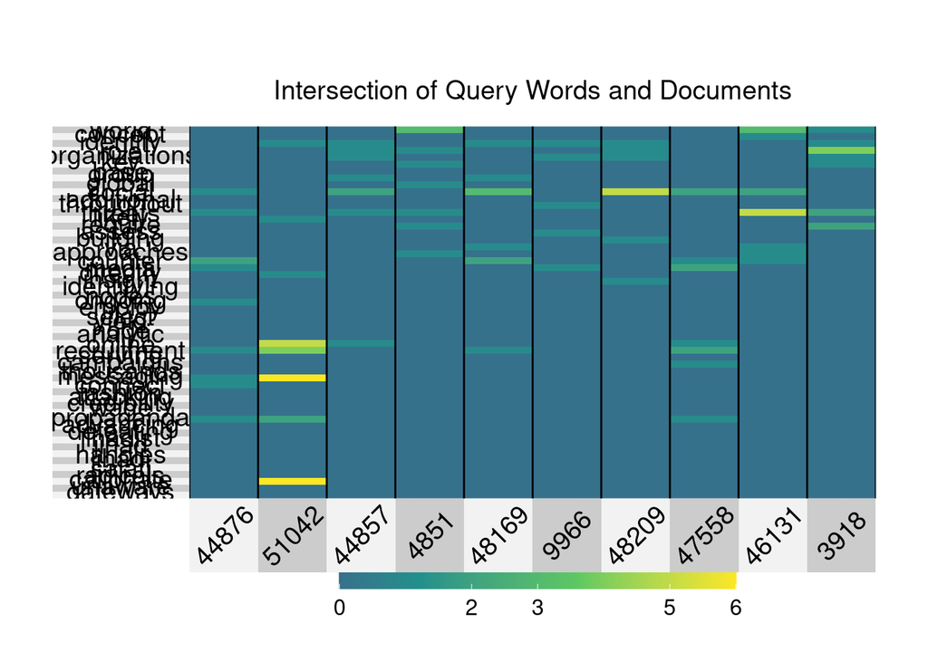

```r
superheat(t(intersection_matrix), bottom.label.text.angle = 45, title = "Intersection of Query Words and Documents")
```

```r
top10_jaccard_docs <- jaccard_results$id[1:10]
for (doc in top10_jaccard_docs){
  print(thesis_data[thesis_data$id == doc,]$title)
}
```

```
## [1] "The emerging threat of domestic terrorism: a systematic review of evolving needs, threats, and opportunities"
## [1] "Brand Caliphate and recruitment between the genders"
## [1] "Aggressive neighborhood watch or unconventional threat? the Hungarian extreme right-wing self-defense movements"
## [1] "Cooperative security in Northeast Asia: ramifications of change in the U.S. and ROK maritime strategies"
## [1] "Countering the hidden hand: a study of Iranian influence in Iraq"
## [1] "Assessing industry business practices in implementing Radio Frequency Identification (RFID) in the tracking and tracing of pharmaceuticals"
## [1] "Team communication: the social identity approach to collaboration"
## [1] "Reverse migration: Western European Muslim women_\xd1\xe9s flights to ISIL territory"
## [1] "Entropy and self-organization_\xd1\xd3an open system approach to the origins of homeland security threats"
## [1] "Future role of fire service in homeland security"
```

```r
### Cosine Similarity
cosine_sim<-as.vector(sim2(query_dtm, my_corpus_dtm, method = "cosine", norm = "l2"))

cosine_results <- cbind(thesis_data, cosine_sim)
cosine_results <- cosine_results[order(cosine_results$cosine_sim, decreasing=TRUE),]

top10_cosine_docs <- cosine_results$id[1:10]
for (doc in top10_cosine_docs){
  print(thesis_data[thesis_data$id == doc,]$title)
}
```

```
## [1] "The use of social media to maximize energy performance in the United States Marine Corps"
## [1] "Assessing the use of social media in a revolutionary environment"
## [1] "Analysis of Department of Defense social media policy and its impact on operational security"
## [1] "Social media: new spaces for contention in authoritarian systems"
## [1] "The Impacts of Social Media on Citizen Security Behavior in Mexico"
## [1] "Social media's impact on civic engagement in Mexico"
## [1] "The Arab media localizing its democratic potential"
## [1] "Assessing the Impact of Social Media on the 25 January 2011 Egyptian Revolution"
## [1] "Trolling new media: violent extremist groups recruiting through social media"
## [1] "Utilizing Social Media to Further the Nationwide Suspicious Activity Reporting Initiative"
```

```r
combined_corpus <- c(my_corpus, proposal)
length(combined_corpus)
```

```
## [1] 30631
```

```r
combined_corpus_it = itoken(combined_corpus, progressbar = FALSE)
v = create_vocabulary(combined_corpus_it, stopwords = stopwords('en')) %>%
  prune_vocabulary(doc_proportion_max = 0.05, term_count_min = 5)
vectorizer = vocab_vectorizer(v)
combined_corpus_dtm<-create_dtm(combined_corpus_it, vectorizer)

tfidf = TfIdf$new()
combined_dtm_tfidf = fit_transform(combined_corpus_dtm, tfidf)

my_corpus_dtm_tfidf <- combined_dtm_tfidf[1:30630,]     # ID our corpus rows
query_dtm_tfidf <- combined_dtm_tfidf[30630:30631,]       # ID our query row

tfidf_sim <- sim2(query_dtm_tfidf, my_corpus_dtm_tfidf, method = "cosine", norm = "l2")
tfidf_sim<-as.vector(tfidf_sim[2,]) # we only want the last row
tfidf_results <- cbind(thesis_data, tfidf_sim)
tfidf_results <- tfidf_results[order(tfidf_results$tfidf_sim, decreasing=TRUE),]

top10_tfidf_docs <- tfidf_results$id[1:10]
for (doc in top10_tfidf_docs){
  print(thesis_data[thesis_data$id == doc,]$title)
}
```

```
## [1] "Prioritization of Information Assurance (IA) technology in a resource constrained environment"
## [1] "Adaptive architecture for command and control experiment eightDesign, construction, and testing of a hysteresis controlled inverter for paralleling"
## [1] "Refractive conditions of Amazon environment and its effects on ground and airborne radar and ESM systems"
## [1] "Security and efficiency concerns with distributed collaborative networking environments"
## [1] "Military housing privatization initiative lessons learned program : an analysis"
## [1] "An exploratory analysis of littoral combat ships' ability to protect expeditionary strike groups"
## [1] "Correlation between quality management metric and people capability maturity model"
## [1] "Comparison of Design-Build to Design-Bid-Build as a project delivery method"
## [1] "Business process reengineering using knowledge value added in support of the Department of the Navy Chief Information Officer"
## [1] "Obstacle avoidance control in the vertical plane for the REMUS autonomous underwater vehicle"
```

```
Perform a document similarity analysis using Jaccard Similarity, Cosine Similarity, and TF*IDF Cosine Similarity using your example proposal as the “query” and the thesis abstracts in the .csv file as the text in your corpus.

Compare and contrast the results you obtain with the different methods.

Select the approach that you feel is best and write a function that takes as input a block of text (a query) and returns both a sorted list of the top 10 recommended thesis documents (title, abstract, score) and a heatmap graphic that shows the intersection of important words and documents.
```

### Function

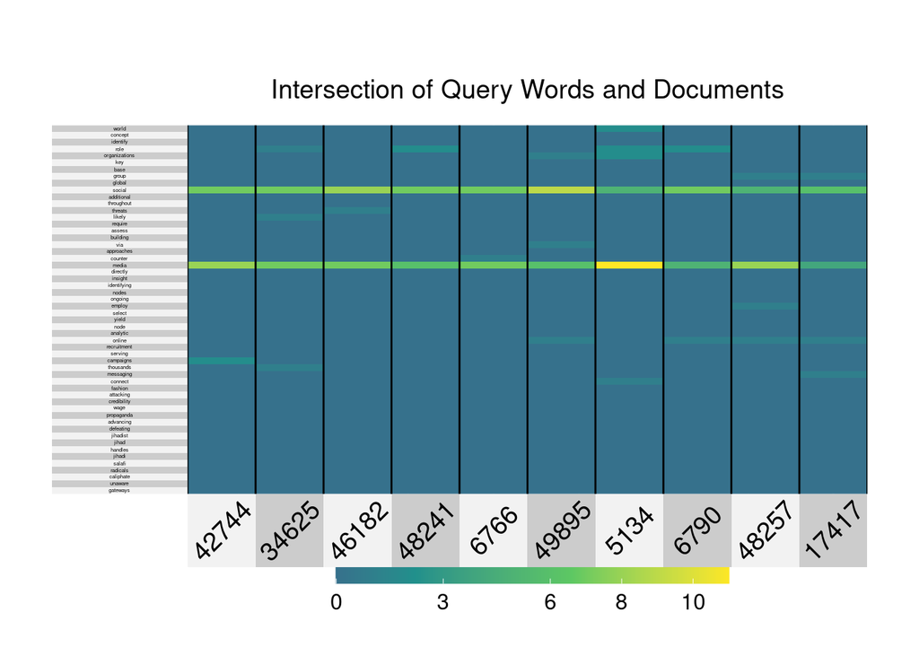

```
##                                                                                              title
## 7168      The use of social media to maximize energy performance in the United States Marine Corps
## 21967                             Assessing the use of social media in a revolutionary environment
## 7414  Analysis of Department of Defense social media policy and its impact on operational security
## 15107                             Social media: new spaces for contention in authoritarian systems
## 24406                           The Impacts of Social Media on Citizen Security Behavior in Mexico
## 30596                                          Social media's impact on civic engagement in Mexico
## 16328                                           The Arab media localizing its democratic potential
## 1371               Assessing the Impact of Social Media on the 25 January 2011 Egyptian Revolution
## 7499                  Trolling new media: violent extremist groups recruiting through social media
## 19066    Utilizing Social Media to Further the Nationwide Suspicious Activity Reporting Initiative
##                                                                                                                                                                                                                                                                                                          …
## 7168                                                                                                                                                                                                                                                                                                     …
## 21967                                                                                                                                                                                                                                                                                                    …
## 7414                                                                                                                                                                                                                                                                                                     …
```

[output cut: 18 more lines]

```r
search_theses = function(query){
  prep_fun = function(x) {
  x %>%
    # make text lower case
    str_to_lower %>%
    # remove non-alphanumeric symbols
    str_replace_all("[^[:alnum:]]", " ") %>%
    # collapse multiple spaces
    str_replace_all("\\s+", " ")
  }

  thesis_data = read.csv("./WK5LabData/FindDocuments/NPSTheses.csv")
  my_corpus = prep_fun(thesis_data$abstract)

  my_corpus_it = itoken(my_corpus, progressbar = FALSE)
  v = create_vocabulary(my_corpus_it, stopwords = stopwords('en')) %>%  # note the removal of stopwords here
      prune_vocabulary(doc_proportion_max = 0.05, term_count_min = 5)   # set some thresholds for minimum occurrence
  vectorizer = vocab_vectorizer(v)
  my_corpus_dtm<-create_dtm(my_corpus_it, vectorizer)   # build a DTM

  query_prep<-prep_fun(query)
  query_it <- itoken(query_prep, progressbar = FALSE)
  query_dtm<-create_dtm(query_it, vectorizer)

  dtm_words <- colnames(query_dtm)
  query_words <- dtm_words[as.numeric(query_dtm > 0) > 0]

  ### Cosine Similarity
  cosine_sim<-as.vector(sim2(query_dtm, my_corpus_dtm, method = "cosine", norm = "l2"))

  cosine_results <- cbind(thesis_data, cosine_sim)
  cosine_results <- cosine_results[order(cosine_results$cosine_sim, decreasing=TRUE),]

  top_10_results = cosine_results[order(cosine_results$cosine_sim, decreasing=TRUE)[1:10],c(13,8,18)]

  #Get top words and documents organized
  top10_docs_id <- cosine_results$id[1:10]
  top10_docs_index <- as.numeric(rownames(top_10_results)[1:10])
  word_index <- which(as.numeric(query_dtm > 0) > 0)
  words <- colnames(query_dtm)[word_index]

  #### Make a matrix containing the intersection of our top words and our top documents
  intersection_list <- list()
  for (i in 1:length(top10_docs_index)){
    if (sum(top10_docs_index[i])>0) intersection_list[[i]] <- my_corpus_dtm[top10_docs_index[i],word_index]
  }
  # Filter out rows with all zero entries
  non_zero_rows <- sapply(intersection_list, function(x) any(x != 0))
  intersection_matrix <- do.call(rbind, intersection_list[non_zero_rows])
  rownames(intersection_matrix) <- top10_docs_id[non_zero_rows]

  head(intersection_matrix)

  superheat(t(intersection_matrix), bottom.label.text.angle = 45, left.label.text.size = 1, title = "Intersection of Query Words and Documents")
  return(top_10_results)
}

search_theses(proposal)
```

### Questions

Please provide a written discussion of the following in your written submission (no more than one page):

```
Clearly identify the proposal you chose as your example
```

W17_4, Social Network Analysis of terrorist orgs

```
Provide a table etc. of results that compare/contrast the results returned by the three methods
```

```r
print('Jaccard Method')
```

```
## [1] "Jaccard Method"
```

```r
for (doc in top10_jaccard_docs){
  print(thesis_data[thesis_data$id == doc,]$title)
}
```

```
## [1] "The emerging threat of domestic terrorism: a systematic review of evolving needs, threats, and opportunities"
## [1] "Brand Caliphate and recruitment between the genders"
## [1] "Aggressive neighborhood watch or unconventional threat? the Hungarian extreme right-wing self-defense movements"
## [1] "Cooperative security in Northeast Asia: ramifications of change in the U.S. and ROK maritime strategies"
## [1] "Countering the hidden hand: a study of Iranian influence in Iraq"
## [1] "Assessing industry business practices in implementing Radio Frequency Identification (RFID) in the tracking and tracing of pharmaceuticals"
## [1] "Team communication: the social identity approach to collaboration"
## [1] "Reverse migration: Western European Muslim women_\xd1\xe9s flights to ISIL territory"
## [1] "Entropy and self-organization_\xd1\xd3an open system approach to the origins of homeland security threats"
## [1] "Future role of fire service in homeland security"
```

```r
print('Cosine Method')
```

```
## [1] "Cosine Method"
```

```r
for (doc in top10_cosine_docs){
  print(thesis_data[thesis_data$id == doc,]$title)
}
```

```
## [1] "The use of social media to maximize energy performance in the United States Marine Corps"
## [1] "Assessing the use of social media in a revolutionary environment"
## [1] "Analysis of Department of Defense social media policy and its impact on operational security"
## [1] "Social media: new spaces for contention in authoritarian systems"
## [1] "The Impacts of Social Media on Citizen Security Behavior in Mexico"
## [1] "Social media's impact on civic engagement in Mexico"
## [1] "The Arab media localizing its democratic potential"
## [1] "Assessing the Impact of Social Media on the 25 January 2011 Egyptian Revolution"
## [1] "Trolling new media: violent extremist groups recruiting through social media"
## [1] "Utilizing Social Media to Further the Nationwide Suspicious Activity Reporting Initiative"
```

```r
print('TFIDF Method')
```

```
## [1] "TFIDF Method"
```

```r
for (doc in top10_tfidf_docs){
  print(thesis_data[thesis_data$id == doc,]$title)
}
```

```
## [1] "Prioritization of Information Assurance (IA) technology in a resource constrained environment"
## [1] "Adaptive architecture for command and control experiment eightDesign, construction, and testing of a hysteresis controlled inverter for paralleling"
## [1] "Refractive conditions of Amazon environment and its effects on ground and airborne radar and ESM systems"
## [1] "Security and efficiency concerns with distributed collaborative networking environments"
## [1] "Military housing privatization initiative lessons learned program : an analysis"
## [1] "An exploratory analysis of littoral combat ships' ability to protect expeditionary strike groups"
## [1] "Correlation between quality management metric and people capability maturity model"
## [1] "Comparison of Design-Build to Design-Bid-Build as a project delivery method"
## [1] "Business process reengineering using knowledge value added in support of the Department of the Navy Chief Information Officer"
## [1] "Obstacle avoidance control in the vertical plane for the REMUS autonomous underwater vehicle"
```

```
Describe the method you think is best given your analysis of the example and why you believe this method is best for the situation.
```

Cosine similarity seems to produce the most relevant documents for this use case. Most of the returned results have to do with social media or social media analysis

```
Describe the procedure you would use to choose between these three methods if you had to actually build this system for NPS (might require more time and people than you have available to you this week)
```

Sample a set of proposals currently available from TPO and apply the three methods to them. Then have a panel of people score the relevance of the returned set of similar theses and pick the method that has the highest overall score.

```
Provide the results of your function (on a second page) when you apply your function/procedure to a new thesis proposal. Identify the thesis proposal you used as your new query (should be different than the one above). Include the resulting graphic in your writeup and provide the resulting “Top 10 Table” as a .csv attachment named YourLastName_FirstInitial_QueryResults.csv
```

```r
new_proposal = read.table("./WK5LabData/FindDocuments/W17_5.txt", sep="\t")
new_proposal
```

```
##                                                                                                                                                                                                                                                                                                          …
## 1 Talent management is a current, relevant issue military unit leaders face. The number of human resources available--particularly those with beneficial or required experiences and skills--are limited, and as a result leaders must invest deliberate thought and consideration into how they build te…
```

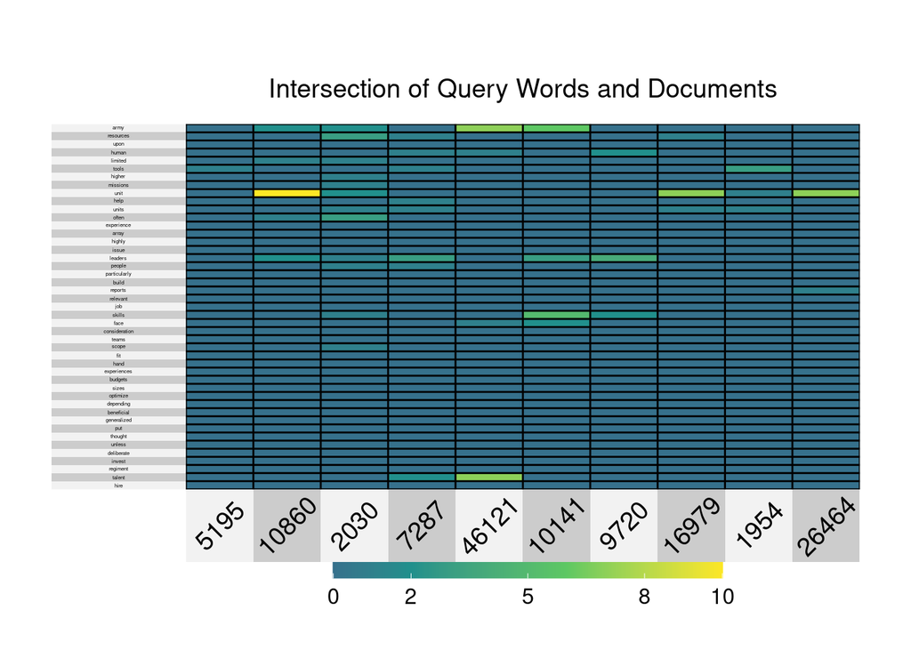

```
##                                                                                                                                                      title
## 16344                                                               Defining a simulation capability hierarchy for the modeling of a SeaBase Enabler (SBE)
## 10034                                                                 Modeling tactical level combat using a Multi-agent System Design Paradigm (GI Agent)
## 23235                            Games for training leveraging commercial off the shelf multiplayer gaming software for infantry squad collective training
## 9129                                                        High Value Talent: Identifying, Developing, and Retaining Naval Special Warfare's Best Leaders
## 30382                                                                                                   Getting it right: revamping Army talent management
## 9824                                                                          An identification of interpersonal skills for building Army civilian leaders
## 25040 Network centric operations and Naval Officers of the future : a first order analysis of desired knowledge, skills, abilities, and personality traits
## 26641                                                Evaluation of the Coast Guard Subhead 30.00 program as a resource management system at the small unit
## 23212                           First responder readiness : a systems approach to readiness assessment using model based vulnerability analysis techniques
## 5773                              The DoD unit cost initiative: a Navy overview, economic analysis, and review of base operations support cost allocation.
##                                                                                                                                                                                                                                                                                                          …
## 16344                                                                                                                                                                                                                                                                                                    …
## 10034 In the past 60 years the Army has undergone a major reorganization eight times at the divisional level and numerous more times at unit levels below the division. Each time the Army reorganized it's divisions a major testing program was involved. But when a change in organization is done at …
## 23235                                                                                                                                                                                                                                                                                                    …
```

[output cut: 18 more lines]

```r
search_theses(new_proposal)
```

Submission Instructions

Your submission items for this week’s take-home lab should include:

The code for performing this week’s take home lab saved as LastName_FirstInital_SimilarityCode.R

A (no more than 2 page) report as a .docx or .pdf file that provides answers to the questions above.

YourLastName_FirstInitial_ERResults.csv

YourLastName_FirstInitial_QueryResults.csv